# Model of weight-lifting techniques

jrblankenship

4/3/2021

# Modeling proper exercise movements

## Summary

The goal of this study is to generate a model of exercise, a dumbbell biceps curl, using data collected from participants asked to preform exercises correctly and incorrectly, with parameters for types of incorrect movements. Movement was detected by monitors on the host, utilizing glove, armband, and belt sensors, as well as on the dumbell used for exercise. Participants were asked to lift the dumbbell in one of five ways: correctly (A), throwing elbows to the front (B), lifting (C) or lowering (D) the dumbbell only half way, or throwing hips to the front (E). Each participant lifted in each manner ten times and their progress was monitored by an experienced weightlifter. The original paper the data was pulled from can be found [here](http://groupware.les.inf.puc-rio.br/public/papers/2013.Velloso.QAR-WLE.pdf). Two machine learning methods, random forest and boosting, were used to model the data and predict unmarked activities.

## Data processing and splitting the training set

```r
train <- read.csv(url("https://d396qusza40orc.cloudfront.net/predmachlearn/pml-training.csv"))
test <- read.csv(url("https://d396qusza40orc.cloudfront.net/predmachlearn/pml-testing.csv"))
dim(train)
```

```
## [1] 19622   160
```

```r
set.seed(123)
library(caret)
inTrain <- createDataPartition(y = train$classe, p = 0.7, list = FALSE)
training <- train[inTrain,]
traintest <- train[-inTrain,]
```

Data for the analysis was downloaded from the course website. Because the “test” set was not amenable to cross-validation, the training set was partitioned into a training set (70% of the data) and a testing set (30% of the data). The data from the testing subset was reserved for cross-validation.

## Cleaning the data

```r
head(training)
summary(training)
colnames(training)[colSums(is.na(training)) > 0] #columns that have any NAs.
colnames(training)[colSums(is.na(training)) > (length(training$classe)/2)] #columns in which more than 50% are NAs
```

A quick scan of the training set revealed that a number of columns contained numerous NAs (67 columns). To determine whether that missing data should be imputed or if those columns should be removed from the analysis, the number of rows with more than 50% NAs was calculated. All 67 rows with NA’s had more than 50% of the data missing, and thus imputing the missing data would likely skew the results. In addition to the NA columns, there were a number of columns missing data for rows that were read as character columns (grepped in the cleaning data chunk below). There were also several columns whose values were specific to the subject, the time the experiment was run, or to the way the data was recorded (the latter represented by the “X” column shown in Figure 1B). All of these columns were removed from the training and testing datasets.

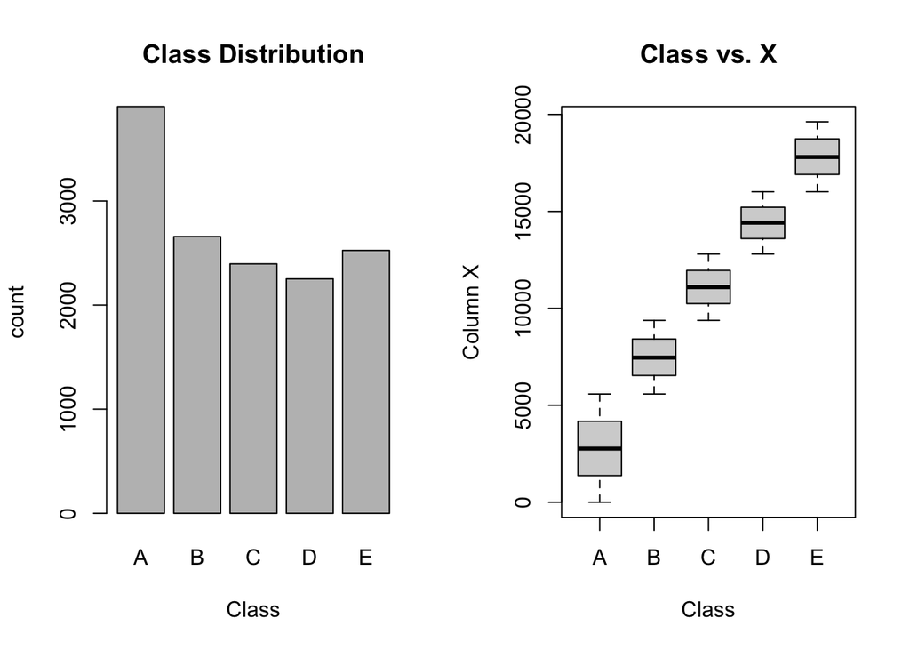

```r
training$classe <- as.factor(training$classe) # to correct the interpretation of this column
par(mfrow = c(1,2))
plot(training$classe, main = "Class Distribution", xlab = "Class", ylab = "count")
plot(training$classe, training$X, main = "Class vs. X", xlab = "Class", ylab = "Column X")
```

```r
library(dplyr)
removethis <- c("X", "user_name", "raw_timestamp_part_1", "raw_timestamp_part_2", "cvtd_timestamp", "new_window")
NAcols <- colnames(training)[colSums(is.na(training)) > (length(training$classe)/2)]
training <- training %>%
  select(-NAcols) %>% #removes columns with NAs
  select(-removethis) #these columns might skew the data/should not be considered in the analysis
training <- training %>%
  select(-grep("skew", names(training), value = TRUE)) %>% #these remove columns with few values
  select(-grep("kurtosis", names(training), value = TRUE)) %>%
  select(-grep("min", names(training), value = TRUE)) %>%
  select(-grep("max", names(training), value = TRUE)) %>%
  select(-grep("amplitude", names(training), value = TRUE))
traintest <- traintest %>%
  select(-NAcols) %>% #removes columns with NAs
  select(-removethis) #these columns might skew the data/should not be considered in the analysis
traintest <- traintest %>%
  select(-grep("skew", names(traintest), value = TRUE)) %>% #these remove columns with few values
  select(-grep("kurtosis", names(traintest), value = TRUE)) %>%
  select(-grep("min", names(traintest), value = TRUE)) %>%
  select(-grep("max", names(traintest), value = TRUE)) %>%
  select(-grep("amplitude", names(traintest), value = TRUE))
```

## Defining models

There are a number of approaches that could be taken to model the exercise data to predict how the exercise was performed, but I chose to investigate two approaches, random forests and boosting. Both approaches are powerful modeling approaches widely used for this type of modeling, although their speed and interpretability are limitations. For this particular modeling exercise, neither speed nor the interpretability of the algorithm used to define the model are required for the success of the approach.

```r
library(parallel)
library(doParallel)
cluster <- makeCluster(detectCores() - 1) # convention to leave 1 core for OS
registerDoParallel(cluster) #these last two help speed up processing
set.seed(2433)
fitControl <- trainControl(method = "cv", number = 3, allowParallel = TRUE)
modrf <- train(classe ~ ., data = training, method = "rf", ntree = 10, prox = TRUE, trcontrol = fitControl) #random forest modeling
stopCluster(cluster)  #this line and the next are needed to turn off parallel processing
registerDoSEQ()
confusionMatrix(modrf)
```

```
## Bootstrapped (25 reps) Confusion Matrix
##
## (entries are percentual average cell counts across resamples)
##
##           Reference
## Prediction    A    B    C    D    E
##          A 28.3  0.1  0.0  0.0  0.0
##          B  0.0 19.1  0.1  0.0  0.0
##          C  0.0  0.1 17.4  0.1  0.0
##          D  0.0  0.0  0.1 16.3  0.1
##          E  0.0  0.0  0.0  0.0 18.1
##
##  Accuracy (average) : 0.9916
```

```r
modboost <- train(classe ~ ., method = "gbm", data = training, verbose = FALSE) #boost modeling
confusionMatrix(modboost)
```

```
## Bootstrapped (25 reps) Confusion Matrix
##
## (entries are percentual average cell counts across resamples)
##
##           Reference
## Prediction    A    B    C    D    E
##          A 28.3  0.2  0.0  0.0  0.0
##          B  0.1 18.8  0.2  0.1  0.1
##          C  0.0  0.3 17.1  0.2  0.0
##          D  0.0  0.0  0.1 16.0  0.2
##          E  0.0  0.0  0.0  0.0 18.1
##
##  Accuracy (average) : 0.983
```

Both of these models exhibited a high degree of accuracy (above 95%) for the training set and were thus used in cross-validation below.

## Cross-validation

One of the concerns of modeling is overfitting to the training set, and thus 30% of the data was withheld from the original training set for cross-validation purposes. Both the random forest and boosting model were tested for performance in the testing set.

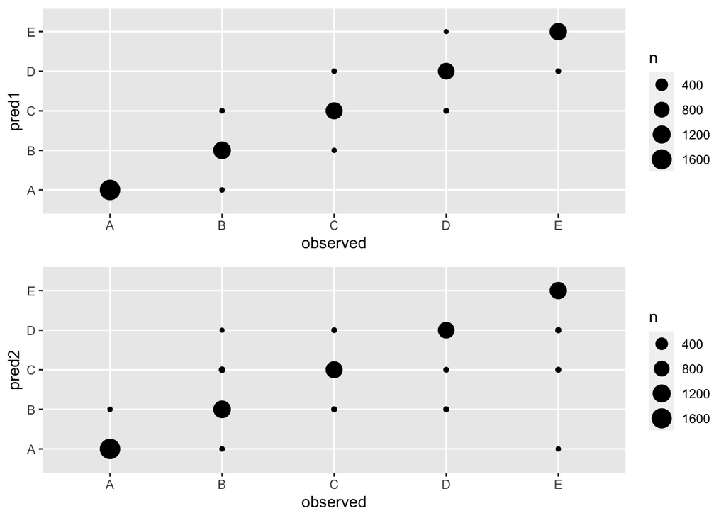

```r
pred1 <- predict(modrf,traintest); pred2 <- predict(modboost,traintest) #predict using the testing set
rfaccuracy <- sum(pred1 == traintest$classe)/length(pred1) # measure of accuracy for rf prediction
baccuracy <- sum(pred2 == traintest$classe)/length(pred2) # measure of accuracy for boost prediction
comptable <- data.frame(pred1, pred2, observed = traintest$classe) # making a table for figures
comp1 <- ggplot(comptable, aes(observed, pred1)) + geom_count()
comp2 <- ggplot(comptable, aes(observed, pred2)) + geom_count()
library(gridExtra)
grid.arrange(comp1, comp2, nrow = 2)
```

**Figure 2** Prediction versus observed call for the random forest (top) and boosted (bottom) models compared to the testing set. The size of the point is in proportion to the number of data points that fall within that value.

In the cross-validation exercise, the random forest model exhibited 0.9964316 accuracy and the boosted model exhibited 0.9877655 accuracy. Figure 2 shows the comparison between the predicted class values for each model and the actual class values. Again, both models performed quite well, with an accuracy above 95%.

## Prediction

The models above were used to define class calls for an unclassified dataset (the original “test” set downloaded from the course website). Prior to using the models to predict the format of the exercise being performed, the same cleaning protocol was used on the test set from the original data.

```r
test2 <- test %>%
  select(-NAcols) %>% #removes columns with NAs
  select(-removethis) #these columns might skew the data/should not be considered in the analysis
test2 <- test2 %>%
  select(-grep("skew", names(test2), value = TRUE)) %>% #these remove columns with few values
  select(-grep("kurtosis", names(test2), value = TRUE)) %>%
  select(-grep("min", names(test2), value = TRUE)) %>%
  select(-grep("max", names(test2), value = TRUE)) %>%
  select(-grep("amplitude", names(test2), value = TRUE))
```

This cleaned data was then subjected to the same modeling used above to produce calls for the type of exercise performed.

```r
pred1test <- predict(modrf,test2); pred2test <- predict(modboost,test2)
numsame <- sum(pred1test == pred2test)/length(pred1test)
```

To determine if any discrepancies existed in the calls between the models, their output was compared. The calls showed a 1:1 similarity, and thus made the same predictions for each row of the test data. Those predictions were B, A, B, A, A, E, D, B, A, A, B, C, B, A, E, E, A, B, B, B. The overlap between the model predictions, coupled with their accuracy measured in both the training and testing sets, gives us high confidence in these predictions.